# Risk Factor Analysis

## Outcome Variable

**Outcome Variable:** whz

## Predictor Variables

**Intervention Variable:** earlybf

**Adjustment Set:**

- arm
- sex
- W_mage
- meducyrs
- feducyrs
- hhwealth_quart
- hfoodsec
- W_mhtcm
- W_mwtkg
- W_mbmi
- vagbrth
- W_gagebrth
- W_birthwt
- W_birthlen
- W_nrooms
- W_nchldlt5
- brthmon
- W_parity
- impfloor
- impsan
- safeh20
- delta_W_mage
- delta_meducyrs
- delta_feducyrs
- delta_hhwealth_quart
- delta_hfoodsec
- delta_W_mhtcm
- delta_W_mwtkg
- delta_W_mbmi
- delta_vagbrth
- delta_W_gagebrth
- delta_W_birthwt
- delta_W_birthlen
- delta_W_nrooms
- delta_W_nchldlt5
- delta_brthmon
- delta_W_parity
- delta_impfloor
- delta_impsan
- delta_safeh20

## Stratifying Variables

The analysis was stratified on these variable(s):

- agecat
- studyid
- country

## Data Summary

| agecat | studyid | country | earlybf | n_cell | n |
| --- | --- | --- | --- | --- | --- |
| Birth | ki0047075b-MAL-ED | BANGLADESH | 1 | 140 | 214 |
| Birth | ki0047075b-MAL-ED | BANGLADESH | 0 | 74 | 214 |
| Birth | ki0047075b-MAL-ED | BRAZIL | 1 | 26 | 62 |
| Birth | ki0047075b-MAL-ED | BRAZIL | 0 | 36 | 62 |
| Birth | ki0047075b-MAL-ED | INDIA | 1 | 31 | 44 |
| Birth | ki0047075b-MAL-ED | INDIA | 0 | 13 | 44 |
| Birth | ki0047075b-MAL-ED | NEPAL | 1 | 14 | 26 |
| Birth | ki0047075b-MAL-ED | NEPAL | 0 | 12 | 26 |
| Birth | ki0047075b-MAL-ED | PERU | 1 | 172 | 228 |
| Birth | ki0047075b-MAL-ED | PERU | 0 | 56 | 228 |
| Birth | ki0047075b-MAL-ED | SOUTH AFRICA | 1 | 69 | 110 |
| Birth | ki0047075b-MAL-ED | SOUTH AFRICA | 0 | 41 | 110 |
| Birth | ki0047075b-MAL-ED | TANZANIA, UNITED REPUBLIC OF | 1 | 103 | 115 |
| Birth | ki0047075b-MAL-ED | TANZANIA, UNITED REPUBLIC OF | 0 | 12 | 115 |
| Birth | ki1000109-EE | PAKISTAN | 1 | 36 | 170 |
| Birth | ki1000109-EE | PAKISTAN | 0 | 134 | 170 |
| Birth | ki1000304b-SAS-CompFeed | INDIA | 1 | 79 | 1072 |
| Birth | ki1000304b-SAS-CompFeed | INDIA | 0 | 993 | 1072 |
| Birth | ki1017093c-NIH-Crypto | BANGLADESH | 1 | 613 | 707 |
| Birth | ki1017093c-NIH-Crypto | BANGLADESH | 0 | 94 | 707 |
| Birth | ki1113344-GMS-Nepal | NEPAL | 1 | 171 | 586 |
| Birth | ki1113344-GMS-Nepal | NEPAL | 0 | 415 | 586 |
| Birth | ki1126311-ZVITAMBO | ZIMBABWE | 1 | 6142 | 11514 |
| Birth | ki1126311-ZVITAMBO | ZIMBABWE | 0 | 5372 | 11514 |
| Birth | kiGH5241-JiVitA-3 | BANGLADESH | 1 | 105 | 17943 |
| Birth | kiGH5241-JiVitA-3 | BANGLADESH | 0 | 17838 | 17943 |
| Birth | kiGH5241-JiVitA-4 | BANGLADESH | 1 | 1624 | 2396 |
| Birth | kiGH5241-JiVitA-4 | BANGLADESH | 0 | 772 | 2396 |
| 6 months | ki0047075b-MAL-ED | BANGLADESH | 1 | 147 | 240 |
| 6 months | ki0047075b-MAL-ED | BANGLADESH | 0 | 93 | 240 |

[output cut: 52 more lines]

The following strata were considered:

- agecat: 24 months, studyid: ki0047075b-MAL-ED, country: BANGLADESH
- agecat: 24 months, studyid: ki0047075b-MAL-ED, country: BRAZIL
- agecat: 24 months, studyid: ki0047075b-MAL-ED, country: INDIA
- agecat: 24 months, studyid: ki0047075b-MAL-ED, country: NEPAL
- agecat: 24 months, studyid: ki0047075b-MAL-ED, country: PERU
- agecat: 24 months, studyid: ki0047075b-MAL-ED, country: SOUTH AFRICA
- agecat: 24 months, studyid: ki0047075b-MAL-ED, country: TANZANIA, UNITED REPUBLIC OF
- agecat: 24 months, studyid: ki1000109-EE, country: PAKISTAN
- agecat: 24 months, studyid: ki1017093c-NIH-Crypto, country: BANGLADESH
- agecat: 24 months, studyid: ki1113344-GMS-Nepal, country: NEPAL
- agecat: 24 months, studyid: ki1126311-ZVITAMBO, country: ZIMBABWE
- agecat: 24 months, studyid: kiGH5241-JiVitA-3, country: BANGLADESH
- agecat: 24 months, studyid: kiGH5241-JiVitA-4, country: BANGLADESH
- agecat: 6 months, studyid: ki0047075b-MAL-ED, country: BANGLADESH
- agecat: 6 months, studyid: ki0047075b-MAL-ED, country: BRAZIL
- agecat: 6 months, studyid: ki0047075b-MAL-ED, country: INDIA
- agecat: 6 months, studyid: ki0047075b-MAL-ED, country: NEPAL
- agecat: 6 months, studyid: ki0047075b-MAL-ED, country: PERU
- agecat: 6 months, studyid: ki0047075b-MAL-ED, country: SOUTH AFRICA
- agecat: 6 months, studyid: ki0047075b-MAL-ED, country: TANZANIA, UNITED REPUBLIC OF
- agecat: 6 months, studyid: ki1000109-EE, country: PAKISTAN
- agecat: 6 months, studyid: ki1000304b-SAS-CompFeed, country: INDIA
- agecat: 6 months, studyid: ki1017093c-NIH-Crypto, country: BANGLADESH
- agecat: 6 months, studyid: ki1113344-GMS-Nepal, country: NEPAL
- agecat: 6 months, studyid: ki1126311-ZVITAMBO, country: ZIMBABWE
- agecat: 6 months, studyid: kiGH5241-JiVitA-3, country: BANGLADESH
- agecat: 6 months, studyid: kiGH5241-JiVitA-4, country: BANGLADESH
- agecat: Birth, studyid: ki0047075b-MAL-ED, country: BANGLADESH
- agecat: Birth, studyid: ki0047075b-MAL-ED, country: BRAZIL
- agecat: Birth, studyid: ki0047075b-MAL-ED, country: INDIA
- agecat: Birth, studyid: ki0047075b-MAL-ED, country: NEPAL
- agecat: Birth, studyid: ki0047075b-MAL-ED, country: PERU
- agecat: Birth, studyid: ki0047075b-MAL-ED, country: SOUTH AFRICA
- agecat: Birth, studyid: ki0047075b-MAL-ED, country: TANZANIA, UNITED REPUBLIC OF
- agecat: Birth, studyid: ki1000109-EE, country: PAKISTAN
- agecat: Birth, studyid: ki1000304b-SAS-CompFeed, country: INDIA
- agecat: Birth, studyid: ki1017093c-NIH-Crypto, country: BANGLADESH
- agecat: Birth, studyid: ki1113344-GMS-Nepal, country: NEPAL
- agecat: Birth, studyid: ki1126311-ZVITAMBO, country: ZIMBABWE
- agecat: Birth, studyid: kiGH5241-JiVitA-3, country: BANGLADESH
- agecat: Birth, studyid: kiGH5241-JiVitA-4, country: BANGLADESH

### Dropped Strata

Some strata were dropped due to rare outcomes:

- agecat: 24 months, studyid: kiGH5241-JiVitA-3, country: BANGLADESH

## Methods Detail

We’re interested in the causal parameters $E[Y_a]$ for all values of $a \in \mathcal{A}$. These parameters represent the mean outcome if, possibly contrary to fact, we intervened to set all units to have $A=a$. Under the randomization and positivity assumptions, these are identified by the statistical parameters $\psi_a=E_W[E_{Y|A,W}(Y|A=a,W)]$. In addition, we’re interested in the mean of $Y$, $E[Y]$ under no intervention (the observed mean). We will estimate these parameters by using SuperLearner to fit the relevant likelihood factors – $E_{Y|A,W}(Y|A=a,W)$ and $p(A=a|W)$, and then updating our likelihood fit using a joint TMLE.

For unadjusted analyses ($W=\{\}$), initial likelihoods were estimated using Lrnr_glm to estimate the simple $E(Y|A)$ and Lrnr_mean to estimate $p(A)$. For adjusted analyses, a small library containing Lrnr_glmnet, Lrnr_xgboost, and Lrnr_mean was used.

# Results Detail

## Results Plots

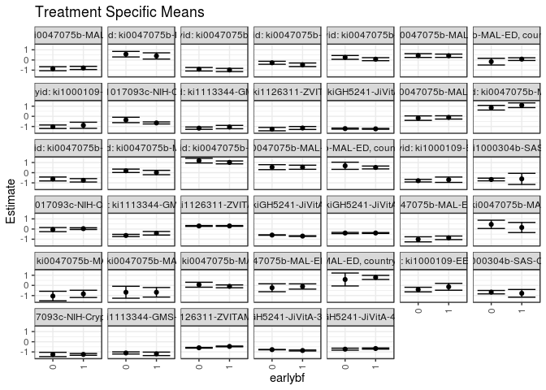

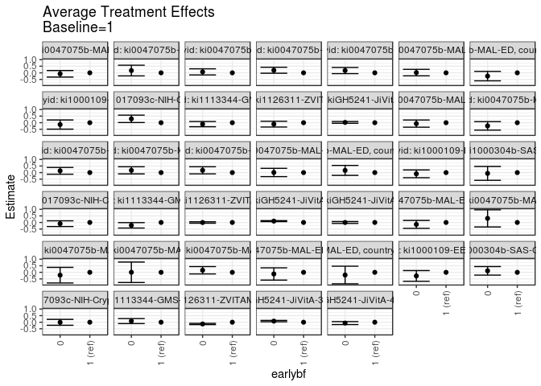

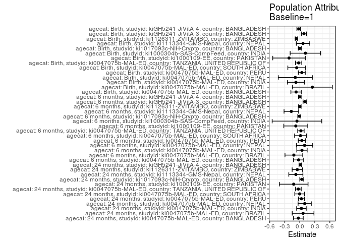

## Results Table

### Parameter: TSM

| agecat | studyid | country | intervention_level | baseline_level | estimate | ci_lower | ci_upper |
| --- | --- | --- | --- | --- | --- | --- | --- |
| Birth | ki0047075b-MAL-ED | BANGLADESH | 1 | NA | -0.8653378 | -1.0407560 | -0.6899195 |
| Birth | ki0047075b-MAL-ED | BANGLADESH | 0 | NA | -1.0138909 | -1.2646640 | -0.7631179 |
| Birth | ki0047075b-MAL-ED | BRAZIL | 1 | NA | 0.1519932 | -0.3451617 | 0.6491482 |
| Birth | ki0047075b-MAL-ED | BRAZIL | 0 | NA | 0.4608595 | 0.0532434 | 0.8684755 |
| Birth | ki0047075b-MAL-ED | INDIA | 1 | NA | -0.8349009 | -1.1919349 | -0.4778669 |
| Birth | ki0047075b-MAL-ED | INDIA | 0 | NA | -1.0504016 | -1.5212702 | -0.5795329 |
| Birth | ki0047075b-MAL-ED | NEPAL | 1 | NA | -0.6791605 | -1.1517549 | -0.2065660 |
| Birth | ki0047075b-MAL-ED | NEPAL | 0 | NA | -0.6751318 | -1.2634120 | -0.0868516 |
| Birth | ki0047075b-MAL-ED | PERU | 1 | NA | -0.0926231 | -0.2318411 | 0.0465949 |
| Birth | ki0047075b-MAL-ED | PERU | 0 | NA | 0.0656982 | -0.1768532 | 0.3082496 |
| Birth | ki0047075b-MAL-ED | SOUTH AFRICA | 1 | NA | -0.1077111 | -0.3670741 | 0.1516519 |
| Birth | ki0047075b-MAL-ED | SOUTH AFRICA | 0 | NA | -0.2318053 | -0.6214992 | 0.1578886 |
| Birth | ki0047075b-MAL-ED | TANZANIA, UNITED REPUBLIC OF | 1 | NA | 0.7850598 | 0.5816138 | 0.9885059 |
| Birth | ki0047075b-MAL-ED | TANZANIA, UNITED REPUBLIC OF | 0 | NA | 0.5806812 | -0.0551499 | 1.2165123 |
| Birth | ki1000109-EE | PAKISTAN | 1 | NA | -0.1379883 | -0.4757136 | 0.1997369 |
| Birth | ki1000109-EE | PAKISTAN | 0 | NA | -0.4103506 | -0.6360803 | -0.1846209 |
| Birth | ki1000304b-SAS-CompFeed | INDIA | 1 | NA | -0.7803988 | -1.1572587 | -0.4035389 |
| Birth | ki1000304b-SAS-CompFeed | INDIA | 0 | NA | -0.6662675 | -0.8343427 | -0.4981923 |
| Birth | ki1017093c-NIH-Crypto | BANGLADESH | 1 | NA | -1.2450594 | -1.3346529 | -1.1554658 |
| Birth | ki1017093c-NIH-Crypto | BANGLADESH | 0 | NA | -1.2523342 | -1.4626739 | -1.0419944 |
| Birth | ki1113344-GMS-Nepal | NEPAL | 1 | NA | -1.1909744 | -1.3603803 | -1.0215684 |
| Birth | ki1113344-GMS-Nepal | NEPAL | 0 | NA | -1.1047253 | -1.2079663 | -1.0014843 |
| Birth | ki1126311-ZVITAMBO | ZIMBABWE | 1 | NA | -0.4589661 | -0.4942145 | -0.4237178 |
| Birth | ki1126311-ZVITAMBO | ZIMBABWE | 0 | NA | -0.5931514 | -0.6311151 | -0.5551877 |
| Birth | kiGH5241-JiVitA-3 | BANGLADESH | 1 | NA | -0.8611737 | -0.9094644 | -0.8128831 |
| Birth | kiGH5241-JiVitA-3 | BANGLADESH | 0 | NA | -0.7773276 | -0.7968071 | -0.7578482 |
| Birth | kiGH5241-JiVitA-4 | BANGLADESH | 1 | NA | -0.6671311 | -0.7264068 | -0.6078553 |
| Birth | kiGH5241-JiVitA-4 | BANGLADESH | 0 | NA | -0.7320261 | -0.8297526 | -0.6342996 |
| 6 months | ki0047075b-MAL-ED | BANGLADESH | 1 | NA | -0.1076329 | -0.2687429 | 0.0534772 |
| 6 months | ki0047075b-MAL-ED | BANGLADESH | 0 | NA | -0.1763624 | -0.3962904 | 0.0435656 |
| 6 months | ki0047075b-MAL-ED | BRAZIL | 1 | NA | 1.0902823 | 0.8583689 | 1.3221956 |
| 6 months | ki0047075b-MAL-ED | BRAZIL | 0 | NA | 0.8481357 | 0.6188675 | 1.0774038 |
| 6 months | ki0047075b-MAL-ED | INDIA | 1 | NA | -0.7518910 | -0.9211525 | -0.5826295 |
| 6 months | ki0047075b-MAL-ED | INDIA | 0 | NA | -0.6187351 | -0.8101969 | -0.4272733 |
| 6 months | ki0047075b-MAL-ED | NEPAL | 1 | NA | 0.0151157 | -0.1985333 | 0.2287647 |
| 6 months | ki0047075b-MAL-ED | NEPAL | 0 | NA | 0.1849159 | 0.0174122 | 0.3524196 |
| 6 months | ki0047075b-MAL-ED | PERU | 1 | NA | 1.0123839 | 0.8689242 | 1.1558435 |
| 6 months | ki0047075b-MAL-ED | PERU | 0 | NA | 1.1847744 | 0.9552322 | 1.4143166 |
| 6 months | ki0047075b-MAL-ED | SOUTH AFRICA | 1 | NA | 0.5355197 | 0.3339798 | 0.7370596 |
| 6 months | ki0047075b-MAL-ED | SOUTH AFRICA | 0 | NA | 0.5432584 | 0.3005868 | 0.7859300 |
| 6 months | ki0047075b-MAL-ED | TANZANIA, UNITED REPUBLIC OF | 1 | NA | 0.5135139 | 0.3723010 | 0.6547268 |
| 6 months | ki0047075b-MAL-ED | TANZANIA, UNITED REPUBLIC OF | 0 | NA | 0.6796890 | 0.3285990 | 1.0307791 |
| 6 months | ki1000109-EE | PAKISTAN | 1 | NA | -0.6929292 | -0.9576528 | -0.4282055 |
| 6 months | ki1000109-EE | PAKISTAN | 0 | NA | -0.7868295 | -0.9143088 | -0.6593502 |
| 6 months | ki1000304b-SAS-CompFeed | INDIA | 1 | NA | -0.6097313 | -1.1597375 | -0.0597251 |
| 6 months | ki1000304b-SAS-CompFeed | INDIA | 0 | NA | -0.6712896 | -0.8039023 | -0.5386770 |
| 6 months | ki1017093c-NIH-Crypto | BANGLADESH | 1 | NA | 0.0400119 | -0.0452784 | 0.1253022 |
| 6 months | ki1017093c-NIH-Crypto | BANGLADESH | 0 | NA | -0.0521271 | -0.2550655 | 0.1508113 |
| 6 months | ki1113344-GMS-Nepal | NEPAL | 1 | NA | -0.4155277 | -0.5893439 | -0.2417114 |
| 6 months | ki1113344-GMS-Nepal | NEPAL | 0 | NA | -0.6343475 | -0.7420761 | -0.5266189 |
| 6 months | ki1126311-ZVITAMBO | ZIMBABWE | 1 | NA | 0.3060705 | 0.2693326 | 0.3428084 |
| 6 months | ki1126311-ZVITAMBO | ZIMBABWE | 0 | NA | 0.3029013 | 0.2622512 | 0.3435515 |
| 6 months | kiGH5241-JiVitA-3 | BANGLADESH | 1 | NA | -0.6948948 | -0.7260304 | -0.6637593 |
| 6 months | kiGH5241-JiVitA-3 | BANGLADESH | 0 | NA | -0.5933407 | -0.6133747 | -0.5733067 |
| 6 months | kiGH5241-JiVitA-4 | BANGLADESH | 1 | NA | -0.3907200 | -0.4352858 | -0.3461543 |
| 6 months | kiGH5241-JiVitA-4 | BANGLADESH | 0 | NA | -0.3919986 | -0.4531790 | -0.3308182 |
| 24 months | ki0047075b-MAL-ED | BANGLADESH | 1 | NA | -0.7855220 | -0.9430379 | -0.6280061 |
| 24 months | ki0047075b-MAL-ED | BANGLADESH | 0 | NA | -0.8615428 | -1.0570432 | -0.6660424 |
| 24 months | ki0047075b-MAL-ED | BRAZIL | 1 | NA | 0.3965525 | 0.0891243 | 0.7039808 |
| 24 months | ki0047075b-MAL-ED | BRAZIL | 0 | NA | 0.5689347 | 0.2955173 | 0.8423520 |
| 24 months | ki0047075b-MAL-ED | INDIA | 1 | NA | -0.9846264 | -1.1409285 | -0.8283244 |
| 24 months | ki0047075b-MAL-ED | INDIA | 0 | NA | -0.9122641 | -1.0839627 | -0.7405654 |
| 24 months | ki0047075b-MAL-ED | NEPAL | 1 | NA | -0.4731960 | -0.6494696 | -0.2969225 |
| 24 months | ki0047075b-MAL-ED | NEPAL | 0 | NA | -0.2775637 | -0.4239600 | -0.1311674 |
| 24 months | ki0047075b-MAL-ED | PERU | 1 | NA | 0.0785973 | -0.0704566 | 0.2276512 |
| 24 months | ki0047075b-MAL-ED | PERU | 0 | NA | 0.2522507 | 0.0644624 | 0.4400390 |
| 24 months | ki0047075b-MAL-ED | SOUTH AFRICA | 1 | NA | 0.4178125 | 0.2546754 | 0.5809495 |
| 24 months | ki0047075b-MAL-ED | SOUTH AFRICA | 0 | NA | 0.4343739 | 0.2493260 | 0.6194218 |
| 24 months | ki0047075b-MAL-ED | TANZANIA, UNITED REPUBLIC OF | 1 | NA | 0.0839516 | -0.0507194 | 0.2186226 |
| 24 months | ki0047075b-MAL-ED | TANZANIA, UNITED REPUBLIC OF | 0 | NA | -0.1664000 | -0.4986891 | 0.1658892 |
| 24 months | ki1000109-EE | PAKISTAN | 1 | NA | -0.8828481 | -1.1836549 | -0.5820412 |
| 24 months | ki1000109-EE | PAKISTAN | 0 | NA | -1.0248342 | -1.1973770 | -0.8522914 |
| 24 months | ki1017093c-NIH-Crypto | BANGLADESH | 1 | NA | -0.6498292 | -0.7502764 | -0.5493821 |
| 24 months | ki1017093c-NIH-Crypto | BANGLADESH | 0 | NA | -0.3549899 | -0.6208707 | -0.0891091 |
| 24 months | ki1113344-GMS-Nepal | NEPAL | 1 | NA | -1.0556937 | -1.2200760 | -0.8913114 |
| 24 months | ki1113344-GMS-Nepal | NEPAL | 0 | NA | -1.1648769 | -1.2772967 | -1.0524572 |
| 24 months | ki1126311-ZVITAMBO | ZIMBABWE | 1 | NA | -1.1476494 | -1.2924944 | -1.0028044 |
| 24 months | ki1126311-ZVITAMBO | ZIMBABWE | 0 | NA | -1.2571118 | -1.4215323 | -1.0926913 |
| 24 months | kiGH5241-JiVitA-4 | BANGLADESH | 1 | NA | -1.2319380 | -1.2722094 | -1.1916666 |
| 24 months | kiGH5241-JiVitA-4 | BANGLADESH | 0 | NA | -1.2088927 | -1.2626330 | -1.1551523 |

### Parameter: E(Y)

| agecat | studyid | country | intervention_level | baseline_level | estimate | ci_lower | ci_upper |
| --- | --- | --- | --- | --- | --- | --- | --- |
| Birth | ki0047075b-MAL-ED | BANGLADESH | NA | NA | -0.9390654 | -1.0847642 | -0.7933666 |
| Birth | ki0047075b-MAL-ED | BRAZIL | NA | NA | 0.4029032 | 0.0896793 | 0.7161272 |
| Birth | ki0047075b-MAL-ED | INDIA | NA | NA | -0.9122727 | -1.1899971 | -0.6345483 |
| Birth | ki0047075b-MAL-ED | NEPAL | NA | NA | -0.7684615 | -1.1257770 | -0.4111460 |
| Birth | ki0047075b-MAL-ED | PERU | NA | NA | -0.0520175 | -0.1725298 | 0.0684947 |
| Birth | ki0047075b-MAL-ED | SOUTH AFRICA | NA | NA | -0.1690000 | -0.3880340 | 0.0500340 |
| Birth | ki0047075b-MAL-ED | TANZANIA, UNITED REPUBLIC OF | NA | NA | 0.7624348 | 0.5710709 | 0.9537986 |
| Birth | ki1000109-EE | PAKISTAN | NA | NA | -0.3522059 | -0.5428560 | -0.1615557 |
| Birth | ki1000304b-SAS-CompFeed | INDIA | NA | NA | -0.6676026 | -0.8422097 | -0.4929956 |
| Birth | ki1017093c-NIH-Crypto | BANGLADESH | NA | NA | -1.2441513 | -1.3281130 | -1.1601897 |
| Birth | ki1113344-GMS-Nepal | NEPAL | NA | NA | -1.1260580 | -1.2184297 | -1.0336863 |
| Birth | ki1126311-ZVITAMBO | ZIMBABWE | NA | NA | -0.5262098 | -0.5537283 | -0.4986913 |
| Birth | kiGH5241-JiVitA-3 | BANGLADESH | NA | NA | -0.7778811 | -0.7969145 | -0.7588476 |
| Birth | kiGH5241-JiVitA-4 | BANGLADESH | NA | NA | -0.6886269 | -0.7410452 | -0.6362086 |
| 6 months | ki0047075b-MAL-ED | BANGLADESH | NA | NA | -0.1316250 | -0.2604010 | -0.0028490 |
| 6 months | ki0047075b-MAL-ED | BRAZIL | NA | NA | 0.9720774 | 0.8078144 | 1.1363403 |
| 6 months | ki0047075b-MAL-ED | INDIA | NA | NA | -0.7079979 | -0.8344175 | -0.5815783 |
| 6 months | ki0047075b-MAL-ED | NEPAL | NA | NA | 0.1104308 | -0.0208643 | 0.2417259 |
| 6 months | ki0047075b-MAL-ED | PERU | NA | NA | 1.0528816 | 0.9313005 | 1.1744626 |
| 6 months | ki0047075b-MAL-ED | SOUTH AFRICA | NA | NA | 0.5500267 | 0.3964966 | 0.7035568 |
| 6 months | ki0047075b-MAL-ED | TANZANIA, UNITED REPUBLIC OF | NA | NA | 0.5362213 | 0.4049390 | 0.6675036 |
| 6 months | ki1000109-EE | PAKISTAN | NA | NA | -0.7725778 | -0.8877440 | -0.6574117 |
| 6 months | ki1000304b-SAS-CompFeed | INDIA | NA | NA | -0.6657084 | -0.8024377 | -0.5289791 |
| 6 months | ki1017093c-NIH-Crypto | BANGLADESH | NA | NA | 0.0297622 | -0.0491685 | 0.1086930 |
| 6 months | ki1113344-GMS-Nepal | NEPAL | NA | NA | -0.5843738 | -0.6761994 | -0.4925481 |
| 6 months | ki1126311-ZVITAMBO | ZIMBABWE | NA | NA | 0.3072633 | 0.2799882 | 0.3345385 |
| 6 months | kiGH5241-JiVitA-3 | BANGLADESH | NA | NA | -0.5935161 | -0.6130518 | -0.5739805 |
| 6 months | kiGH5241-JiVitA-4 | BANGLADESH | NA | NA | -0.3898055 | -0.4270507 | -0.3525603 |
| 24 months | ki0047075b-MAL-ED | BANGLADESH | NA | NA | -0.8141706 | -0.9363085 | -0.6920327 |
| 24 months | ki0047075b-MAL-ED | BRAZIL | NA | NA | 0.4626233 | 0.2567495 | 0.6684971 |
| 24 months | ki0047075b-MAL-ED | INDIA | NA | NA | -0.9516520 | -1.0670654 | -0.8362385 |
| 24 months | ki0047075b-MAL-ED | NEPAL | NA | NA | -0.3749123 | -0.4886073 | -0.2612173 |
| 24 months | ki0047075b-MAL-ED | PERU | NA | NA | 0.1111982 | -0.0118399 | 0.2342362 |
| 24 months | ki0047075b-MAL-ED | SOUTH AFRICA | NA | NA | 0.4152943 | 0.2928804 | 0.5377083 |
| 24 months | ki0047075b-MAL-ED | TANZANIA, UNITED REPUBLIC OF | NA | NA | 0.0547975 | -0.0703378 | 0.1799328 |
| 24 months | ki1000109-EE | PAKISTAN | NA | NA | -1.0044512 | -1.1543739 | -0.8545285 |
| 24 months | ki1017093c-NIH-Crypto | BANGLADESH | NA | NA | -0.6103502 | -0.7050157 | -0.5156847 |
| 24 months | ki1113344-GMS-Nepal | NEPAL | NA | NA | -1.1339602 | -1.2266932 | -1.0412272 |
| 24 months | ki1126311-ZVITAMBO | ZIMBABWE | NA | NA | -1.1970712 | -1.3045749 | -1.0895676 |
| 24 months | kiGH5241-JiVitA-4 | BANGLADESH | NA | NA | -1.2231088 | -1.2549632 | -1.1912543 |

### Parameter: ATE

| agecat | studyid | country | intervention_level | baseline_level | estimate | ci_lower | ci_upper |
| --- | --- | --- | --- | --- | --- | --- | --- |
| Birth | ki0047075b-MAL-ED | BANGLADESH | 1 | 1 | 0.0000000 | 0.0000000 | 0.0000000 |
| Birth | ki0047075b-MAL-ED | BANGLADESH | 0 | 1 | -0.1485531 | -0.4495701 | 0.1524638 |
| Birth | ki0047075b-MAL-ED | BRAZIL | 1 | 1 | 0.0000000 | 0.0000000 | 0.0000000 |
| Birth | ki0047075b-MAL-ED | BRAZIL | 0 | 1 | 0.3088662 | -0.3453957 | 0.9631282 |
| Birth | ki0047075b-MAL-ED | INDIA | 1 | 1 | 0.0000000 | 0.0000000 | 0.0000000 |
| Birth | ki0047075b-MAL-ED | INDIA | 0 | 1 | -0.2155007 | -0.8097827 | 0.3787814 |
| Birth | ki0047075b-MAL-ED | NEPAL | 1 | 1 | 0.0000000 | 0.0000000 | 0.0000000 |
| Birth | ki0047075b-MAL-ED | NEPAL | 0 | 1 | 0.0040287 | -0.7745596 | 0.7826169 |
| Birth | ki0047075b-MAL-ED | PERU | 1 | 1 | 0.0000000 | 0.0000000 | 0.0000000 |
| Birth | ki0047075b-MAL-ED | PERU | 0 | 1 | 0.1583213 | -0.1220582 | 0.4387009 |
| Birth | ki0047075b-MAL-ED | SOUTH AFRICA | 1 | 1 | 0.0000000 | 0.0000000 | 0.0000000 |
| Birth | ki0047075b-MAL-ED | SOUTH AFRICA | 0 | 1 | -0.1240943 | -0.5917360 | 0.3435474 |
| Birth | ki0047075b-MAL-ED | TANZANIA, UNITED REPUBLIC OF | 1 | 1 | 0.0000000 | 0.0000000 | 0.0000000 |
| Birth | ki0047075b-MAL-ED | TANZANIA, UNITED REPUBLIC OF | 0 | 1 | -0.2043787 | -0.8740744 | 0.4653171 |
| Birth | ki1000109-EE | PAKISTAN | 1 | 1 | 0.0000000 | 0.0000000 | 0.0000000 |
| Birth | ki1000109-EE | PAKISTAN | 0 | 1 | -0.2723623 | -0.6790631 | 0.1343386 |
| Birth | ki1000304b-SAS-CompFeed | INDIA | 1 | 1 | 0.0000000 | 0.0000000 | 0.0000000 |
| Birth | ki1000304b-SAS-CompFeed | INDIA | 0 | 1 | 0.1141313 | -0.2121205 | 0.4403832 |
| Birth | ki1017093c-NIH-Crypto | BANGLADESH | 1 | 1 | 0.0000000 | 0.0000000 | 0.0000000 |
| Birth | ki1017093c-NIH-Crypto | BANGLADESH | 0 | 1 | -0.0072748 | -0.2311782 | 0.2166286 |
| Birth | ki1113344-GMS-Nepal | NEPAL | 1 | 1 | 0.0000000 | 0.0000000 | 0.0000000 |
| Birth | ki1113344-GMS-Nepal | NEPAL | 0 | 1 | 0.0862490 | -0.1025296 | 0.2750277 |
| Birth | ki1126311-ZVITAMBO | ZIMBABWE | 1 | 1 | 0.0000000 | 0.0000000 | 0.0000000 |
| Birth | ki1126311-ZVITAMBO | ZIMBABWE | 0 | 1 | -0.1341853 | -0.1820467 | -0.0863238 |
| Birth | kiGH5241-JiVitA-3 | BANGLADESH | 1 | 1 | 0.0000000 | 0.0000000 | 0.0000000 |
| Birth | kiGH5241-JiVitA-3 | BANGLADESH | 0 | 1 | 0.0838461 | 0.0319355 | 0.1357567 |
| Birth | kiGH5241-JiVitA-4 | BANGLADESH | 1 | 1 | 0.0000000 | 0.0000000 | 0.0000000 |
| Birth | kiGH5241-JiVitA-4 | BANGLADESH | 0 | 1 | -0.0648950 | -0.1764115 | 0.0466215 |
| 6 months | ki0047075b-MAL-ED | BANGLADESH | 1 | 1 | 0.0000000 | 0.0000000 | 0.0000000 |
| 6 months | ki0047075b-MAL-ED | BANGLADESH | 0 | 1 | -0.0687295 | -0.3419232 | 0.2044641 |
| 6 months | ki0047075b-MAL-ED | BRAZIL | 1 | 1 | 0.0000000 | 0.0000000 | 0.0000000 |
| 6 months | ki0047075b-MAL-ED | BRAZIL | 0 | 1 | -0.2421466 | -0.5670898 | 0.0827966 |
| 6 months | ki0047075b-MAL-ED | INDIA | 1 | 1 | 0.0000000 | 0.0000000 | 0.0000000 |
| 6 months | ki0047075b-MAL-ED | INDIA | 0 | 1 | 0.1331560 | -0.1230638 | 0.3893757 |
| 6 months | ki0047075b-MAL-ED | NEPAL | 1 | 1 | 0.0000000 | 0.0000000 | 0.0000000 |
| 6 months | ki0047075b-MAL-ED | NEPAL | 0 | 1 | 0.1698002 | -0.1021064 | 0.4417068 |
| 6 months | ki0047075b-MAL-ED | PERU | 1 | 1 | 0.0000000 | 0.0000000 | 0.0000000 |
| 6 months | ki0047075b-MAL-ED | PERU | 0 | 1 | 0.1723905 | -0.0987492 | 0.4435303 |
| 6 months | ki0047075b-MAL-ED | SOUTH AFRICA | 1 | 1 | 0.0000000 | 0.0000000 | 0.0000000 |
| 6 months | ki0047075b-MAL-ED | SOUTH AFRICA | 0 | 1 | 0.0077387 | -0.3088142 | 0.3242916 |
| 6 months | ki0047075b-MAL-ED | TANZANIA, UNITED REPUBLIC OF | 1 | 1 | 0.0000000 | 0.0000000 | 0.0000000 |
| 6 months | ki0047075b-MAL-ED | TANZANIA, UNITED REPUBLIC OF | 0 | 1 | 0.1661751 | -0.2123447 | 0.5446949 |
| 6 months | ki1000109-EE | PAKISTAN | 1 | 1 | 0.0000000 | 0.0000000 | 0.0000000 |
| 6 months | ki1000109-EE | PAKISTAN | 0 | 1 | -0.0939003 | -0.3879897 | 0.2001891 |
| 6 months | ki1000304b-SAS-CompFeed | INDIA | 1 | 1 | 0.0000000 | 0.0000000 | 0.0000000 |
| 6 months | ki1000304b-SAS-CompFeed | INDIA | 0 | 1 | -0.0615583 | -0.5884850 | 0.4653684 |
| 6 months | ki1017093c-NIH-Crypto | BANGLADESH | 1 | 1 | 0.0000000 | 0.0000000 | 0.0000000 |
| 6 months | ki1017093c-NIH-Crypto | BANGLADESH | 0 | 1 | -0.0921390 | -0.3115847 | 0.1273068 |
| 6 months | ki1113344-GMS-Nepal | NEPAL | 1 | 1 | 0.0000000 | 0.0000000 | 0.0000000 |
| 6 months | ki1113344-GMS-Nepal | NEPAL | 0 | 1 | -0.2188198 | -0.4238397 | -0.0137999 |
| 6 months | ki1126311-ZVITAMBO | ZIMBABWE | 1 | 1 | 0.0000000 | 0.0000000 | 0.0000000 |
| 6 months | ki1126311-ZVITAMBO | ZIMBABWE | 0 | 1 | -0.0031692 | -0.0574933 | 0.0511549 |
| 6 months | kiGH5241-JiVitA-3 | BANGLADESH | 1 | 1 | 0.0000000 | 0.0000000 | 0.0000000 |
| 6 months | kiGH5241-JiVitA-3 | BANGLADESH | 0 | 1 | 0.1015541 | 0.0642339 | 0.1388744 |
| 6 months | kiGH5241-JiVitA-4 | BANGLADESH | 1 | 1 | 0.0000000 | 0.0000000 | 0.0000000 |
| 6 months | kiGH5241-JiVitA-4 | BANGLADESH | 0 | 1 | -0.0012786 | -0.0739827 | 0.0714256 |
| 24 months | ki0047075b-MAL-ED | BANGLADESH | 1 | 1 | 0.0000000 | 0.0000000 | 0.0000000 |
| 24 months | ki0047075b-MAL-ED | BANGLADESH | 0 | 1 | -0.0760208 | -0.3252083 | 0.1731667 |
| 24 months | ki0047075b-MAL-ED | BRAZIL | 1 | 1 | 0.0000000 | 0.0000000 | 0.0000000 |
| 24 months | ki0047075b-MAL-ED | BRAZIL | 0 | 1 | 0.1723821 | -0.2341460 | 0.5789103 |
| 24 months | ki0047075b-MAL-ED | INDIA | 1 | 1 | 0.0000000 | 0.0000000 | 0.0000000 |
| 24 months | ki0047075b-MAL-ED | INDIA | 0 | 1 | 0.0723624 | -0.1600658 | 0.3047905 |
| 24 months | ki0047075b-MAL-ED | NEPAL | 1 | 1 | 0.0000000 | 0.0000000 | 0.0000000 |
| 24 months | ki0047075b-MAL-ED | NEPAL | 0 | 1 | 0.1956323 | -0.0318053 | 0.4230699 |
| 24 months | ki0047075b-MAL-ED | PERU | 1 | 1 | 0.0000000 | 0.0000000 | 0.0000000 |
| 24 months | ki0047075b-MAL-ED | PERU | 0 | 1 | 0.1736535 | -0.0609857 | 0.4082926 |
| 24 months | ki0047075b-MAL-ED | SOUTH AFRICA | 1 | 1 | 0.0000000 | 0.0000000 | 0.0000000 |
| 24 months | ki0047075b-MAL-ED | SOUTH AFRICA | 0 | 1 | 0.0165615 | -0.2303565 | 0.2634794 |
| 24 months | ki0047075b-MAL-ED | TANZANIA, UNITED REPUBLIC OF | 1 | 1 | 0.0000000 | 0.0000000 | 0.0000000 |
| 24 months | ki0047075b-MAL-ED | TANZANIA, UNITED REPUBLIC OF | 0 | 1 | -0.2503515 | -0.6096502 | 0.1089471 |
| 24 months | ki1000109-EE | PAKISTAN | 1 | 1 | 0.0000000 | 0.0000000 | 0.0000000 |
| 24 months | ki1000109-EE | PAKISTAN | 0 | 1 | -0.1419862 | -0.4910982 | 0.2071258 |
| 24 months | ki1017093c-NIH-Crypto | BANGLADESH | 1 | 1 | 0.0000000 | 0.0000000 | 0.0000000 |
| 24 months | ki1017093c-NIH-Crypto | BANGLADESH | 0 | 1 | 0.2948393 | 0.0126707 | 0.5770080 |
| 24 months | ki1113344-GMS-Nepal | NEPAL | 1 | 1 | 0.0000000 | 0.0000000 | 0.0000000 |
| 24 months | ki1113344-GMS-Nepal | NEPAL | 0 | 1 | -0.1091832 | -0.3076616 | 0.0892951 |
| 24 months | ki1126311-ZVITAMBO | ZIMBABWE | 1 | 1 | 0.0000000 | 0.0000000 | 0.0000000 |
| 24 months | ki1126311-ZVITAMBO | ZIMBABWE | 0 | 1 | -0.1094624 | -0.3292125 | 0.1102876 |
| 24 months | kiGH5241-JiVitA-4 | BANGLADESH | 1 | 1 | 0.0000000 | 0.0000000 | 0.0000000 |
| 24 months | kiGH5241-JiVitA-4 | BANGLADESH | 0 | 1 | 0.0230453 | -0.0446183 | 0.0907089 |

### Parameter: PAR

| agecat | studyid | country | intervention_level | baseline_level | estimate | ci_lower | ci_upper |
| --- | --- | --- | --- | --- | --- | --- | --- |
| Birth | ki0047075b-MAL-ED | BANGLADESH | 1 | NA | -0.0737276 | -0.1776186 | 0.0301633 |
| Birth | ki0047075b-MAL-ED | BRAZIL | 1 | NA | 0.2509100 | -0.1477573 | 0.6495773 |
| Birth | ki0047075b-MAL-ED | INDIA | 1 | NA | -0.0773718 | -0.2477994 | 0.0930558 |
| Birth | ki0047075b-MAL-ED | NEPAL | 1 | NA | -0.0893011 | -0.4297089 | 0.2511068 |
| Birth | ki0047075b-MAL-ED | PERU | 1 | NA | 0.0406056 | -0.0285271 | 0.1097383 |
| Birth | ki0047075b-MAL-ED | SOUTH AFRICA | 1 | NA | -0.0612889 | -0.2384574 | 0.1158796 |
| Birth | ki0047075b-MAL-ED | TANZANIA, UNITED REPUBLIC OF | 1 | NA | -0.0226251 | -0.0857819 | 0.0405318 |
| Birth | ki1000109-EE | PAKISTAN | 1 | NA | -0.2142175 | -0.5393927 | 0.1109577 |
| Birth | ki1000304b-SAS-CompFeed | INDIA | 1 | NA | 0.1127962 | -0.1920694 | 0.4176618 |
| Birth | ki1017093c-NIH-Crypto | BANGLADESH | 1 | NA | 0.0009080 | -0.0285656 | 0.0303817 |
| Birth | ki1113344-GMS-Nepal | NEPAL | 1 | NA | 0.0649163 | -0.0686812 | 0.1985138 |
| Birth | ki1126311-ZVITAMBO | ZIMBABWE | 1 | NA | -0.0672437 | -0.0909170 | -0.0435704 |
| Birth | kiGH5241-JiVitA-3 | BANGLADESH | 1 | NA | 0.0832927 | 0.0326797 | 0.1339057 |
| Birth | kiGH5241-JiVitA-4 | BANGLADESH | 1 | NA | -0.0214958 | -0.0574423 | 0.0144507 |
| 6 months | ki0047075b-MAL-ED | BANGLADESH | 1 | NA | -0.0239921 | -0.1255180 | 0.0775338 |
| 6 months | ki0047075b-MAL-ED | BRAZIL | 1 | NA | -0.1182049 | -0.2954079 | 0.0589981 |
| 6 months | ki0047075b-MAL-ED | INDIA | 1 | NA | 0.0438932 | -0.0592756 | 0.1470619 |
| 6 months | ki0047075b-MAL-ED | NEPAL | 1 | NA | 0.0953151 | -0.0674603 | 0.2580905 |
| 6 months | ki0047075b-MAL-ED | PERU | 1 | NA | 0.0404977 | -0.0301300 | 0.1111254 |
| 6 months | ki0047075b-MAL-ED | SOUTH AFRICA | 1 | NA | 0.0145070 | -0.1036956 | 0.1327095 |
| 6 months | ki0047075b-MAL-ED | TANZANIA, UNITED REPUBLIC OF | 1 | NA | 0.0227074 | -0.0414849 | 0.0868996 |
| 6 months | ki1000109-EE | PAKISTAN | 1 | NA | -0.0796487 | -0.3187932 | 0.1594959 |
| 6 months | ki1000304b-SAS-CompFeed | INDIA | 1 | NA | -0.0559771 | -0.5513990 | 0.4394448 |
| 6 months | ki1017093c-NIH-Crypto | BANGLADESH | 1 | NA | -0.0102496 | -0.0398324 | 0.0193331 |
| 6 months | ki1113344-GMS-Nepal | NEPAL | 1 | NA | -0.1688461 | -0.3140533 | -0.0236389 |
| 6 months | ki1126311-ZVITAMBO | ZIMBABWE | 1 | NA | 0.0011928 | -0.0241557 | 0.0265413 |
| 6 months | kiGH5241-JiVitA-3 | BANGLADESH | 1 | NA | 0.1013787 | 0.0649796 | 0.1377778 |
| 6 months | kiGH5241-JiVitA-4 | BANGLADESH | 1 | NA | 0.0009145 | -0.0251758 | 0.0270048 |
| 24 months | ki0047075b-MAL-ED | BANGLADESH | 1 | NA | -0.0286486 | -0.1260823 | 0.0687850 |
| 24 months | ki0047075b-MAL-ED | BRAZIL | 1 | NA | 0.0660707 | -0.1510807 | 0.2832222 |
| 24 months | ki0047075b-MAL-ED | INDIA | 1 | NA | 0.0329744 | -0.0627496 | 0.1286985 |
| 24 months | ki0047075b-MAL-ED | NEPAL | 1 | NA | 0.0982837 | -0.0337680 | 0.2303355 |
| 24 months | ki0047075b-MAL-ED | PERU | 1 | NA | 0.0326009 | -0.0272509 | 0.0924527 |
| 24 months | ki0047075b-MAL-ED | SOUTH AFRICA | 1 | NA | -0.0025181 | -0.0992970 | 0.0942608 |
| 24 months | ki0047075b-MAL-ED | TANZANIA, UNITED REPUBLIC OF | 1 | NA | -0.0291541 | -0.0868942 | 0.0285860 |
| 24 months | ki1000109-EE | PAKISTAN | 1 | NA | -0.1216032 | -0.4081332 | 0.1649269 |
| 24 months | ki1017093c-NIH-Crypto | BANGLADESH | 1 | NA | 0.0394790 | 0.0009680 | 0.0779901 |
| 24 months | ki1113344-GMS-Nepal | NEPAL | 1 | NA | -0.0782665 | -0.2188783 | 0.0623453 |
| 24 months | ki1126311-ZVITAMBO | ZIMBABWE | 1 | NA | -0.0494219 | -0.1525042 | 0.0536604 |
| 24 months | kiGH5241-JiVitA-4 | BANGLADESH | 1 | NA | 0.0088292 | -0.0154326 | 0.0330910 |